# Epigenomics EPICS Practical

Pierre Wensel

13 June, 2024

UVic-UCC Course: Epigenomcs

Introduction In medicine, hepatopulmonary syndrome is a syndrome of shortness of breath and hypoxemia (low oxygen levels in the blood of the arteries) caused by vasodilation (broadening of the blood vessels) in the lungs of patients with liver disease. Dyspnea and hypoxemia are worse in the upright position (which is called platypnea and orthodeoxia, respectively).

The following publication was cited and cross-referenceed to identify potential biomarkers: Mendoza N, Rivas E, Rodriguez-Roisin R, Garcia T, Bruguera M, Agusti A, et al. (2021) Liver epigenome changes in patients with hepatopulmonary syndrome: A pilot study. PLoS ONE 16(2): e0245046. https://doi.org/10.1371/journal.pone.0245046

None of the 802,688 DNA probes analyzed in the case control comparison achieved a significant False Discovery Rate (FDR). WGCNA identified 5 co-methylated gene-modules associated to HPS markers, mainly related to nervous and neuroendocrine system, apoptotic processes, gut bacterial translocation, angiogenesis and vascular remodeling ontologies. To conclude, HPS is associated with nervous/neuroendocrine system and vascular remodeling related liver epigenetic changes

The exercise will be structured in blocks: BLOCK1: Quality Control 1. How many samples passed the quality control? Can you specify which is the procedure you followed? 2. How many probes pass the quality control? Can you specify which is the procedure you followed? 3. Can you predict the sex of the samples? Do they correlate with sex in the phenodata? BLOCK2: Analysis (in order to standardize, normalize by Quantiles). Do not expect huge differences in this case, hence use nominal pvalue to establish differential analysis control instead of FDR. 1. How many CpgS are differentially methylated without considering covariates (age, sex…)? That means all, promoter, and promoter plus island. 2. How many CpGs are differentially methylated considering covariates (look in the Phenodata)? That means all, promoter, and promoter plus island (Hint: use limma design matrix to assign covariates) Question: Which do you think is the best method, considering covariates or not, that give you the best approach to get differential methylated CpGs that explain the disease. Discuss it properly 3. Consider prom+islands diff methylated Cpgs using covariates adjustment, in terms of Biological pathways, do you think they are related to the disease? Specify which procedure you used it and also, please discuss properly. 4. Consider to establish a threshod using phenodata FVC column ONLY in HPS patients: i-e less than 90 and more than 90 value. Forced vital capacity (FVC) is the volume of air that can forcibly be blown out after full inspiration, measured in liters. It is an important issue valoring the disease, Do you find dmps in promoter + islands (remember, work with nominal pval)? Are they good candidates for biomarkers? (heatmaps, GO enrichment,..) compared to the previous analysis?

## 0.1 R Markdown

```r
 ##############SET DIRECTORIES, RENAME AND READ IN TARGETS FILE AND IDAT DATA FILES:


setwd("C:/Users/User/Desktop/R/Metabolomics/")
getwd()
```

```
## [1] "C:/Users/User/Desktop/R/Metabolomics"
```

```r
idat.folder <- "Epigenomics_EPIC/idats"
#change for your path directory
#Note: I renamed the course-provided samples.csv file to "targets.csv
targets <- read.metharray.sheet(base=idat.folder)
```

```
## [read.metharray.sheet] Found the following CSV files:
```

```
## [1] "Epigenomics_EPIC/idats/targets.csv"
```

```r
class(targets)
```

```
## [1] "data.frame"
```

```r
targets
```

```
##    SampleName            Basename Disease_state bmi fvc age gender ecocardio
## 1  GSM4969761 200514040133_R03C01           HPS  31  85  50   male  Positive
## 2  GSM4969762 200514040133_R04C01       Control  23 105  56 female    No eco
## 3  GSM4969763 200517480058_R03C01       Control  25  86  53 female    No eco
## 4  GSM4969764 200517480058_R05C01       Control  25  99  42   male    No eco
## 5  GSM4969765 200517480058_R06C01       Control  26 115  55   male    No eco
## 6  GSM4969766 200517480058_R07C01           HPS  25  99  45 female  Positive
## 7  GSM4969767 200517480058_R08C01           HPS  24 117  41   male  Positive
## 8  GSM4969768 200517480077_R01C01       Control  30  94  59   male    No eco
## 9  GSM4969769 200517480077_R03C01           HPS  34  91  63   male  Positive
## 10 GSM4969770 200517480077_R04C01           HPS  23  85  61 female  Positive
## 11 GSM4969771 200517480077_R05C01           HPS  23  99  47 female  Positive
## 12 GSM4969772 200517480077_R06C01           HPS  23  85  61   male  Positive
```

```r
#Note: Unlike previous examples involving Illumina440K, there is no "Name" column in "targets.csv"
#Adding a name column with identifiers H and C

#data.met = readRDS(file = "data.met.RDS")
# met matrix
#met <- as.data.frame(SummarizedExperiment::assay(data.met))
## remove probes with NA
#probe.na <- rowSums(is.na(met))
#table(probe.na == 0)
#FALSE   TRUE
#103553 382024
# chose those has no NA values in rows
#probe <- probe.na[probe.na == 0]
#met <- met[row.names(met) %in% names(probe), ]

targets$name<-targets$Basename
targets$name<-paste0(targets$name,c("H","C","C","C","C","H","H","C","H","H","H","H"))

targets
```

```
##    SampleName            Basename Disease_state bmi fvc age gender ecocardio
## 1  GSM4969761 200514040133_R03C01           HPS  31  85  50   male  Positive
## 2  GSM4969762 200514040133_R04C01       Control  23 105  56 female    No eco
## 3  GSM4969763 200517480058_R03C01       Control  25  86  53 female    No eco
## 4  GSM4969764 200517480058_R05C01       Control  25  99  42   male    No eco
## 5  GSM4969765 200517480058_R06C01       Control  26 115  55   male    No eco
## 6  GSM4969766 200517480058_R07C01           HPS  25  99  45 female  Positive
## 7  GSM4969767 200517480058_R08C01           HPS  24 117  41   male  Positive
## 8  GSM4969768 200517480077_R01C01       Control  30  94  59   male    No eco
## 9  GSM4969769 200517480077_R03C01           HPS  34  91  63   male  Positive
## 10 GSM4969770 200517480077_R04C01           HPS  23  85  61 female  Positive
## 11 GSM4969771 200517480077_R05C01           HPS  23  99  47 female  Positive
## 12 GSM4969772 200517480077_R06C01           HPS  23  85  61   male  Positive
##                    name
## 1  200514040133_R03C01H
## 2  200514040133_R04C01C
## 3  200517480058_R03C01C
## 4  200517480058_R05C01C
## 5  200517480058_R06C01C
## 6  200517480058_R07C01H
## 7  200517480058_R08C01H
## 8  200517480077_R01C01C
## 9  200517480077_R03C01H
## 10 200517480077_R04C01H
## 11 200517480077_R05C01H
## 12 200517480077_R06C01H
```

```r
#test1<-test %>% mutate(across(c('Basename'), substr, 24, nchar(Basename)))

targets$Basename <- paste0(c("Class/"),targets$Basename)
#cat("Class/", targets$Basename, sep="")
#targets[] <- lapply(targets, function(x) paste('Class/', x))
#targets[] <- Map(paste, 'Class/', targets)
targets
```

```
##    SampleName                  Basename Disease_state bmi fvc age gender
## 1  GSM4969761 Class/200514040133_R03C01           HPS  31  85  50   male
## 2  GSM4969762 Class/200514040133_R04C01       Control  23 105  56 female
## 3  GSM4969763 Class/200517480058_R03C01       Control  25  86  53 female
## 4  GSM4969764 Class/200517480058_R05C01       Control  25  99  42   male
## 5  GSM4969765 Class/200517480058_R06C01       Control  26 115  55   male
## 6  GSM4969766 Class/200517480058_R07C01           HPS  25  99  45 female
## 7  GSM4969767 Class/200517480058_R08C01           HPS  24 117  41   male
## 8  GSM4969768 Class/200517480077_R01C01       Control  30  94  59   male
## 9  GSM4969769 Class/200517480077_R03C01           HPS  34  91  63   male
## 10 GSM4969770 Class/200517480077_R04C01           HPS  23  85  61 female
## 11 GSM4969771 Class/200517480077_R05C01           HPS  23  99  47 female
## 12 GSM4969772 Class/200517480077_R06C01           HPS  23  85  61   male
##    ecocardio                 name
## 1   Positive 200514040133_R03C01H
## 2     No eco 200514040133_R04C01C
## 3     No eco 200517480058_R03C01C
## 4     No eco 200517480058_R05C01C
## 5     No eco 200517480058_R06C01C
## 6   Positive 200517480058_R07C01H
## 7   Positive 200517480058_R08C01H
## 8     No eco 200517480077_R01C01C
## 9   Positive 200517480077_R03C01H
## 10  Positive 200517480077_R04C01H
## 11  Positive 200517480077_R05C01H
## 12  Positive 200517480077_R06C01H
```

```r
targets$Basename<-gsub("Class/","Epigenomics_EPIC/idats/",targets$Basename)
targets
```

```
##    SampleName                                   Basename Disease_state bmi fvc
## 1  GSM4969761 Epigenomics_EPIC/idats/200514040133_R03C01           HPS  31  85
## 2  GSM4969762 Epigenomics_EPIC/idats/200514040133_R04C01       Control  23 105
## 3  GSM4969763 Epigenomics_EPIC/idats/200517480058_R03C01       Control  25  86
## 4  GSM4969764 Epigenomics_EPIC/idats/200517480058_R05C01       Control  25  99
## 5  GSM4969765 Epigenomics_EPIC/idats/200517480058_R06C01       Control  26 115
## 6  GSM4969766 Epigenomics_EPIC/idats/200517480058_R07C01           HPS  25  99
## 7  GSM4969767 Epigenomics_EPIC/idats/200517480058_R08C01           HPS  24 117
## 8  GSM4969768 Epigenomics_EPIC/idats/200517480077_R01C01       Control  30  94
## 9  GSM4969769 Epigenomics_EPIC/idats/200517480077_R03C01           HPS  34  91
## 10 GSM4969770 Epigenomics_EPIC/idats/200517480077_R04C01           HPS  23  85
## 11 GSM4969771 Epigenomics_EPIC/idats/200517480077_R05C01           HPS  23  99
## 12 GSM4969772 Epigenomics_EPIC/idats/200517480077_R06C01           HPS  23  85
##    age gender ecocardio                 name
## 1   50   male  Positive 200514040133_R03C01H
## 2   56 female    No eco 200514040133_R04C01C
## 3   53 female    No eco 200517480058_R03C01C
## 4   42   male    No eco 200517480058_R05C01C
## 5   55   male    No eco 200517480058_R06C01C
## 6   45 female  Positive 200517480058_R07C01H
## 7   41   male  Positive 200517480058_R08C01H
## 8   59   male    No eco 200517480077_R01C01C
## 9   63   male  Positive 200517480077_R03C01H
## 10  61 female  Positive 200517480077_R04C01H
## 11  47 female  Positive 200517480077_R05C01H
## 12  61   male  Positive 200517480077_R06C01H
```

```r
#targets$Basename<-gsub("Class/","/Epigenomics_EPIC/idats/",targets$Basename)
#targets$Basename<-gsub("Class/","C:/Users/click/OneDrive/Desktop/R_TRANSCIPTOMICS/Epigenomics_EPIC/idats/",targets$Basename)

###loading data

rgset <- read.metharray.exp(targets = targets,verbose = T)
```

```
## [read.metharray] Reading 200514040133_R03C01_Grn.idat
```

```
## [read.metharray] Reading 200514040133_R04C01_Grn.idat
```

```
## [read.metharray] Reading 200517480058_R03C01_Grn.idat
```

```
## [read.metharray] Reading 200517480058_R05C01_Grn.idat
```

```
## [read.metharray] Reading 200517480058_R06C01_Grn.idat
```

```
## [read.metharray] Reading 200517480058_R07C01_Grn.idat
```

```
## [read.metharray] Reading 200517480058_R08C01_Grn.idat
```

```
## [read.metharray] Reading 200517480077_R01C01_Grn.idat
```

```
## [read.metharray] Reading 200517480077_R03C01_Grn.idat
```

```
## [read.metharray] Reading 200517480077_R04C01_Grn.idat
```

```
## [read.metharray] Reading 200517480077_R05C01_Grn.idat
```

```
## [read.metharray] Reading 200517480077_R06C01_Grn.idat
```

```
## [read.metharray] Reading 200514040133_R03C01_Red.idat
```

```
## [read.metharray] Reading 200514040133_R04C01_Red.idat
```

```
## [read.metharray] Reading 200517480058_R03C01_Red.idat
```

```
## [read.metharray] Reading 200517480058_R05C01_Red.idat
```

```
## [read.metharray] Reading 200517480058_R06C01_Red.idat
```

```
## [read.metharray] Reading 200517480058_R07C01_Red.idat
```

```
## [read.metharray] Reading 200517480058_R08C01_Red.idat
```

```
## [read.metharray] Reading 200517480077_R01C01_Red.idat
```

```
## [read.metharray] Reading 200517480077_R03C01_Red.idat
```

```
## [read.metharray] Reading 200517480077_R04C01_Red.idat
```

```
## [read.metharray] Reading 200517480077_R05C01_Red.idat
```

```
## [read.metharray] Reading 200517480077_R06C01_Red.idat
```

```
## [read.metharray] Read idat files in 3.7 seconds
```

```
## [read.metharray] Creating data matrices ... done in 28.2 seconds
## [read.metharray] Instantiating final object ... done in 0.1 seconds
```

```r
rgset
```

```
## class: RGChannelSet
## dim: 1052641 12
## metadata(0):
## assays(2): Green Red
## rownames(1052641): 1600101 1600111 ... 99810990 99810992
## rowData names(0):
## colnames(12): 200514040133_R03C01 200514040133_R04C01 ...
##   200517480077_R05C01 200517480077_R06C01
## colData names(10): SampleName Basename ... name filenames
## Annotation
##   array: IlluminaHumanMethylationEPIC
##   annotation: ilm10b4.hg19
```

```r
####quality control first day

#The class of RGSet is a RGChannelSet object.
#This is the initial object of a minfi analysis that contains the raw intensities in the green and red channels.
#Note that this object contains the intensities of the internal control probes as well.

##################DATA EXPLORATION AND CONVERSION OF OBJECTS ULTIAMTELY FROM rgset to GEnomicRAtioSet:
phenoData <- pData(rgset)

head(phenoData)
```

```
## DataFrame with 6 rows and 10 columns
##                      SampleName               Basename Disease_state       bmi
##                     <character>            <character>   <character> <integer>
## 200514040133_R03C01  GSM4969761 Epigenomics_EPIC/ida..           HPS        31
## 200514040133_R04C01  GSM4969762 Epigenomics_EPIC/ida..       Control        23
## 200517480058_R03C01  GSM4969763 Epigenomics_EPIC/ida..       Control        25
## 200517480058_R05C01  GSM4969764 Epigenomics_EPIC/ida..       Control        25
## 200517480058_R06C01  GSM4969765 Epigenomics_EPIC/ida..       Control        26
## 200517480058_R07C01  GSM4969766 Epigenomics_EPIC/ida..           HPS        25
##                           fvc       age      gender   ecocardio
##                     <integer> <integer> <character> <character>
## 200514040133_R03C01        85        50        male    Positive
## 200514040133_R04C01       105        56      female      No eco
## 200517480058_R03C01        86        53      female      No eco
## 200517480058_R05C01        99        42        male      No eco
## 200517480058_R06C01       115        55        male      No eco
## 200517480058_R07C01        99        45      female    Positive
##                                     name              filenames
##                              <character>            <character>
## 200514040133_R03C01 200514040133_R03C01H Epigenomics_EPIC/ida..
## 200514040133_R04C01 200514040133_R04C01C Epigenomics_EPIC/ida..
## 200517480058_R03C01 200517480058_R03C01C Epigenomics_EPIC/ida..
## 200517480058_R05C01 200517480058_R05C01C Epigenomics_EPIC/ida..
## 200517480058_R06C01 200517480058_R06C01C Epigenomics_EPIC/ida..
## 200517480058_R07C01 200517480058_R07C01H Epigenomics_EPIC/ida..
```

```r
#The RGChannelSet stores also a manifest object that contains the probe design information of the array:

manifest <- getManifest(rgset)
manifest
```

```
## IlluminaMethylationManifest object
## Annotation
##   array: IlluminaHumanMethylationEPIC
## Number of type I probes: 142262
## Number of type II probes: 724574
## Number of control probes: 635
## Number of SNP type I probes: 21
## Number of SNP type II probes: 38
```

```r
####Probes information

getProbeInfo(manifest, type = "I")
```

```
## DataFrame with 142262 rows and 8 columns
##               Name    AddressA    AddressB       Color       NextBase
##        <character> <character> <character> <character> <DNAStringSet>
## 1       cg18478105    46761277    86644198         Grn              C
## 2       cg09835024    16745152    81631976         Red              A
## 3       cg14361672    51800947     7743487         Red              T
## 4       cg01763666    37768834    23754592         Grn              C
## 5       cg12950382     8726444    76660327         Red              A
## ...            ...         ...         ...         ...            ...
## 142258  cg06899844    58695205    89635329         Red              A
## 142259  cg22494081     5672534    22760897         Red              A
## 142260  cg22623303    56736111    11616883         Red              T
## 142261  cg12325588    78754334    35621935         Grn              C
## 142262  cg21064505    92700227    55789279         Red              T
##                      ProbeSeqA               ProbeSeqB      nCpG
##                 <DNAStringSet>          <DNAStringSet> <integer>
## 1      AAATAAATTT...ACAAAAACCA AAATAAATTT...ACGAAAACCG         5
## 2      AATAAACACC...ACAAAAATCA AATAAACGCC...ACAAAAATCG         5
## 3      ATCACTACCT...ACATCCTACA ATCACTACCT...ACATCCTACG         2
## 4      AAACAAAAAT...AAAACAAACA GAACAAAAAT...AAAACAAACG         1
## 5      ATACCAAAAA...CCAAATAACA GTACCGAAAA...CCGAATAACG         3
## ...                        ...                     ...       ...
## 142258 AAAAAAACCA...ACAAAAAACA AAAAAAACCG...ACGAAAAACG         4
## 142259 AAAAACACCC...CAAAACACCA AAAAACGCCC...CGAAACACCG         2
## 142260 AAAACCCCTT...ACAAAAACCA AAAACCCCTT...ACGAAAACCG         2
## 142261 CAAAAACAAC...AAAAATAACA CGAAAACGAC...AAAAATAACG         5
## 142262 CATCCCTCTA...TAACATTCCA CGTCCCTCTA...TAACGTTCCG         4
```

```r
getProbeInfo(manifest, type = "II")
```

```
## DataFrame with 724574 rows and 4 columns
##               Name    AddressA               ProbeSeqA      nCpG
##        <character> <character>          <DNAStringSet> <integer>
## 1       cg07881041    85713262 CTACAAATAC...CTCATTTAAC         0
## 2       cg23229610    21717843 ATAAAATTCT...CAAAAATTCC         0
## 3       cg03513874    29622133 ACAATAAAAT...AAATAATATC         0
## 4       cg05451842    16681196 CRTTCAAATA...AACCCAAAAC         2
## 5       cg14797042     7767973 TTAACAAAAT...TCACTCTAAC         0
## ...            ...         ...                     ...       ...
## 724570  cg23079522    98681180 AAAAAAATAC...AACCCTTTCC         1
## 724571  cg16818145    67613963 CAAAAAACRC...CTTCTAAAAC         2
## 724572  cg14585103    71743112 ATATCTAAAT...AACATTATCC         0
## 724573  cg10633746    72780862 CTTTAAATAC...CATCTCTAAC         0
## 724574  cg12623625    99779128 AAAACATCTA...CCCRTACCTC         1
```

```r
##A MethylSet objects contains only the methylated and unmethylated signals

MSet <- preprocessRaw(rgset)
MSet
```

```
## class: MethylSet
## dim: 866836 12
## metadata(0):
## assays(2): Meth Unmeth
## rownames(866836): cg18478105 cg09835024 ... cg10633746 cg12623625
## rowData names(0):
## colnames(12): 200514040133_R03C01 200514040133_R04C01 ...
##   200517480077_R05C01 200517480077_R06C01
## colData names(10): SampleName Basename ... name filenames
## Annotation
##   array: IlluminaHumanMethylationEPIC
##   annotation: ilm10b4.hg19
## Preprocessing
##   Method: Raw (no normalization or bg correction)
##   minfi version: 1.50.0
##   Manifest version: 0.3.0
```

```r
#A RatioSet object is a class designed to store Beta values and/or M values instead of the methylated and unmethylated signals.
#An optional copy number matrix, CN, the sum of the methylated and unmethylated signals, can be also stored.
#Mapping a MethylSet to a RatioSet may be irreversible, i.e. one cannot be guranteed to retrieve the methylated and unmethylated signals from a RatioSet.
#A RatioSet can be created with the function ratioConvert:

RSet <- ratioConvert(MSet, what = "both", keepCN = TRUE)
RSet
```

```
## class: RatioSet
## dim: 866836 12
## metadata(0):
## assays(3): Beta M CN
## rownames(866836): cg18478105 cg09835024 ... cg10633746 cg12623625
## rowData names(0):
## colnames(12): 200514040133_R03C01 200514040133_R04C01 ...
##   200517480077_R05C01 200517480077_R06C01
## colData names(10): SampleName Basename ... name filenames
## Annotation
##   array: IlluminaHumanMethylationEPIC
##   annotation: ilm10b4.hg19
## Preprocessing
##   Method: Raw (no normalization or bg correction)
##   minfi version: 1.50.0
##   Manifest version: 0.3.0
```

```r
#The functions getBeta, getM and getCN return respectively the Beta value matrix, M value matrix and the Copy Number matrix.
beta <- getBeta(RSet)

head(beta)
```

```
##            200514040133_R03C01 200514040133_R04C01 200517480058_R03C01
## cg18478105          0.03956117          0.11355311          0.04259613
## cg09835024          0.09713101          0.08628006          0.09167205
## cg14361672          0.73503558          0.68343600          0.57176891
## cg01763666          0.85077187          0.79162411          0.82100000
## cg12950382          0.89734256          0.78278198          0.81514138
## cg02115394          0.12133827          0.14555399          0.13125724
##            200517480058_R05C01 200517480058_R06C01 200517480058_R07C01
## cg18478105          0.05513432          0.04121845          0.03582935
## cg09835024          0.08342200          0.10654651          0.07952070
## cg14361672          0.72719221          0.76777688          0.64864401
## cg01763666          0.83663050          0.86082344          0.85313341
## cg12950382          0.91907514          0.79873491          0.87734392
## cg02115394          0.16294936          0.18625562          0.17453153
##            200517480058_R08C01 200517480077_R01C01 200517480077_R03C01
## cg18478105          0.03375191          0.05266238          0.05047734
## cg09835024          0.04480652          0.08490171          0.07766544
## cg14361672          0.76179327          0.69227449          0.69246243
## cg01763666          0.88059956          0.82950192          0.84161418
## cg12950382          0.87853722          0.84371281          0.82157058
## cg02115394          0.12930067          0.14196667          0.15163297
##            200517480077_R04C01 200517480077_R05C01 200517480077_R06C01
## cg18478105          0.04599643          0.06886440          0.04944511
## cg09835024          0.08675405          0.09214385          0.09211776
## cg14361672          0.68897736          0.74394362          0.63861037
## cg01763666          0.85864297          0.72956403          0.79557116
## cg12950382          0.86988235          0.94085507          0.89572321
## cg02115394          0.14947176          0.17307692          0.16453959
```

```r
#GenomicRatioSet

#The function mapToGenome applied to a RatioSet object will add genomic coordinates to each probe together with some additional annotation information.
#The output object is a GenomicRatioSet (class holding M or/and Beta values together with associated genomic coordinates).
#It is possible to merge the manifest object with the genomic locations by setting the option mergeManifest to TRUE.

GRset <- mapToGenome(RSet)
GRset
```

```
## class: GenomicRatioSet
## dim: 865859 12
## metadata(0):
## assays(3): Beta M CN
## rownames(865859): cg14817997 cg26928153 ... cg07587934 cg16855331
## rowData names(0):
## colnames(12): 200514040133_R03C01 200514040133_R04C01 ...
##   200517480077_R05C01 200517480077_R06C01
## colData names(10): SampleName Basename ... name filenames
## Annotation
##   array: IlluminaHumanMethylationEPIC
##   annotation: ilm10b4.hg19
## Preprocessing
##   Method: Raw (no normalization or bg correction)
##   minfi version: 1.50.0
##   Manifest version: 0.3.0
```

```r
beta <- getBeta(GRset)
head(beta)
```

```
##            200514040133_R03C01 200514040133_R04C01 200517480058_R03C01
## cg14817997           0.7857490           0.8596365           0.8630906
## cg26928153           0.8907085           0.8516646           0.8680739
## cg16269199           0.7462932           0.7046275           0.7314500
## cg13869341           0.8595963           0.8747224           0.8378082
## cg14008030           0.6986491           0.6302020           0.6831833
## cg12045430           0.2293752           0.2860000           0.2102656
##            200517480058_R05C01 200517480058_R06C01 200517480058_R07C01
## cg14817997           0.8558397           0.8477696           0.8623158
## cg26928153           0.8538732           0.8960466           0.8830933
## cg16269199           0.6642377           0.6805970           0.6891454
## cg13869341           0.8904063           0.8814660           0.8191428
## cg14008030           0.7221782           0.7380998           0.7472309
## cg12045430           0.2180729           0.1826127           0.2728232
##            200517480058_R08C01 200517480077_R01C01 200517480077_R03C01
## cg14817997           0.8328725           0.8550725           0.8067321
## cg26928153           0.9052777           0.8771211           0.8630022
## cg16269199           0.7361929           0.7000481           0.7318296
## cg13869341           0.9198028           0.8633971           0.8515115
## cg14008030           0.7932229           0.7346430           0.7443338
## cg12045430           0.1314415           0.2273304           0.1908486
##            200517480077_R04C01 200517480077_R05C01 200517480077_R06C01
## cg14817997           0.8087381           0.8257629           0.7882177
## cg26928153           0.8810170           0.8851050           0.8694663
## cg16269199           0.7016216           0.7650291           0.6828979
## cg13869341           0.8536059           0.8605722           0.8408911
## cg14008030           0.7475797           0.7831363           0.8154662
## cg12045430           0.2319002           0.2788643           0.2603108
```

```r
M <- getM(GRset)
class(M)
```

```
## [1] "matrix" "array"
```

```r
head(M)
```

```
##            200514040133_R03C01 200514040133_R04C01 200517480058_R03C01
## cg14817997            1.874766           2.6145588            2.656291
## cg26928153            3.026772           2.5214220            2.718088
## cg16269199            1.556581           1.2543253            1.445568
## cg13869341            2.614078           2.8036971            2.368919
## cg14008030            1.213123           0.7690767            1.108624
## cg12045430           -1.748319          -1.3199089           -1.909155
##            200517480058_R05C01 200517480058_R06C01 200517480058_R07C01
## cg14817997           2.5696666            2.477416            2.646853
## cg26928153           2.5468015            3.107637            2.917208
## cg16269199           0.9842592            1.091423            1.148568
## cg13869341           3.0222996            2.894604            2.179264
## cg14008030           1.3781948            1.494799            1.563734
## cg12045430          -1.8422239           -2.162233           -1.414340
##            200517480058_R08C01 200517480077_R01C01 200517480077_R03C01
## cg14817997            2.317147            2.560715            2.061488
## cg26928153            3.256585            2.835539            2.655211
## cg16269199            1.480601            1.222723            1.448358
## cg13869341            3.519700            2.660037            2.519675
## cg14008030            1.939650            1.469109            1.541688
## cg12045430           -2.724202           -1.765061           -2.083981
##            200517480077_R04C01 200517480077_R05C01 200517480077_R06C01
## cg14817997            2.080123            2.244676            1.896013
## cg26928153            2.888415            2.945533            2.735707
## cg16269199            1.233550            1.703032            1.106722
## cg13869341            2.543712            2.625778            2.401905
## cg14008030            1.566399            1.852475            2.143740
## cg12045430           -1.727790           -1.370708           -1.506684
```

```r
CN <- getCN(GRset)
class(CN)
```

```
## [1] "matrix" "array"
```

```r
head(CN)
```

```
##            200514040133_R03C01 200514040133_R04C01 200517480058_R03C01
## cg14817997            12.59222            12.44009            12.33427
## cg26928153            12.50209            12.21250            12.56605
## cg16269199            12.83052            12.57317            12.52062
## cg13869341            14.66128            14.39981            14.91942
## cg14008030            13.66933            13.67419            13.95520
## cg12045430            14.24963            14.05325            14.67965
##            200517480058_R05C01 200517480058_R06C01 200517480058_R07C01
## cg14817997            12.70714            12.04883            12.79867
## cg26928153            12.73471            12.77972            13.01245
## cg16269199            12.80090            12.78033            12.91270
## cg13869341            14.70596            14.73439            14.85375
## cg14008030            13.88532            13.93397            13.93101
## cg12045430            14.49116            14.54557            14.64380
##            200517480058_R08C01 200517480077_R01C01 200517480077_R03C01
## cg14817997            12.66844            12.13089            11.79969
## cg26928153            12.95474            12.32390            12.53843
## cg16269199            13.13555            12.60525            12.54714
## cg13869341            14.94008            14.67849            14.64222
## cg14008030            14.38303            13.77818            13.75801
## cg12045430            14.66855            14.62171            14.38208
##            200517480077_R04C01 200517480077_R05C01 200517480077_R06C01
## cg14817997            12.88722            12.79584            12.71102
## cg26928153            12.98406            13.20243            13.10115
## cg16269199            12.85331            13.20839            13.03960
## cg13869341            14.66233            14.74026            14.82809
## cg14008030            13.92898            13.96461            13.91681
## cg12045430            14.51410            14.72329            14.60392
```

```r
sampleNames <- sampleNames(GRset)
class(sampleNames)
```

```
## [1] "character"
```

```r
sampleNames
```

```
##  [1] "200514040133_R03C01" "200514040133_R04C01" "200517480058_R03C01"
##  [4] "200517480058_R05C01" "200517480058_R06C01" "200517480058_R07C01"
##  [7] "200517480058_R08C01" "200517480077_R01C01" "200517480077_R03C01"
## [10] "200517480077_R04C01" "200517480077_R05C01" "200517480077_R06C01"
```

```r
probeNames <- featureNames(GRset)
class(probeNames)
```

```
## [1] "character"
```

```r
head(probeNames)
```

```
## [1] "cg14817997" "cg26928153" "cg16269199" "cg13869341" "cg14008030"
## [6] "cg12045430"
```

```r
pheno <- pData(GRset)
pheno
```

```
## DataFrame with 12 rows and 10 columns
##                      SampleName               Basename Disease_state       bmi
##                     <character>            <character>   <character> <integer>
## 200514040133_R03C01  GSM4969761 Epigenomics_EPIC/ida..           HPS        31
## 200514040133_R04C01  GSM4969762 Epigenomics_EPIC/ida..       Control        23
## 200517480058_R03C01  GSM4969763 Epigenomics_EPIC/ida..       Control        25
## 200517480058_R05C01  GSM4969764 Epigenomics_EPIC/ida..       Control        25
## 200517480058_R06C01  GSM4969765 Epigenomics_EPIC/ida..       Control        26
## ...                         ...                    ...           ...       ...
## 200517480077_R01C01  GSM4969768 Epigenomics_EPIC/ida..       Control        30
## 200517480077_R03C01  GSM4969769 Epigenomics_EPIC/ida..           HPS        34
## 200517480077_R04C01  GSM4969770 Epigenomics_EPIC/ida..           HPS        23
## 200517480077_R05C01  GSM4969771 Epigenomics_EPIC/ida..           HPS        23
## 200517480077_R06C01  GSM4969772 Epigenomics_EPIC/ida..           HPS        23
##                           fvc       age      gender   ecocardio
##                     <integer> <integer> <character> <character>
## 200514040133_R03C01        85        50        male    Positive
## 200514040133_R04C01       105        56      female      No eco
## 200517480058_R03C01        86        53      female      No eco
## 200517480058_R05C01        99        42        male      No eco
## 200517480058_R06C01       115        55        male      No eco
## ...                       ...       ...         ...         ...
## 200517480077_R01C01        94        59        male      No eco
## 200517480077_R03C01        91        63        male    Positive
## 200517480077_R04C01        85        61      female    Positive
## 200517480077_R05C01        99        47      female    Positive
## 200517480077_R06C01        85        61        male    Positive
##                                     name              filenames
##                              <character>            <character>
## 200514040133_R03C01 200514040133_R03C01H Epigenomics_EPIC/ida..
## 200514040133_R04C01 200514040133_R04C01C Epigenomics_EPIC/ida..
## 200517480058_R03C01 200517480058_R03C01C Epigenomics_EPIC/ida..
## 200517480058_R05C01 200517480058_R05C01C Epigenomics_EPIC/ida..
## 200517480058_R06C01 200517480058_R06C01C Epigenomics_EPIC/ida..
## ...                                  ...                    ...
## 200517480077_R01C01 200517480077_R01C01C Epigenomics_EPIC/ida..
## 200517480077_R03C01 200517480077_R03C01H Epigenomics_EPIC/ida..
## 200517480077_R04C01 200517480077_R04C01H Epigenomics_EPIC/ida..
## 200517480077_R05C01 200517480077_R05C01H Epigenomics_EPIC/ida..
## 200517480077_R06C01 200517480077_R06C01H Epigenomics_EPIC/ida..
```

```r
gr <- granges(GRset)
head(gr, n= 3)
```

```
## GRanges object with 3 ranges and 0 metadata columns:
##              seqnames    ranges strand
##                 <Rle> <IRanges>  <Rle>
##   cg14817997     chr1     10525      *
##   cg26928153     chr1     10848      *
##   cg16269199     chr1     10850      *
##   -------
##   seqinfo: 24 sequences from hg19 genome; no seqlengths
```

```r
##Full annotation
annotation <- getAnnotation(GRset)

#head(annotation)

names(annotation)
```

```
##  [1] "chr"
##  [2] "pos"
##  [3] "strand"
##  [4] "Name"
##  [5] "AddressA"
##  [6] "AddressB"
##  [7] "ProbeSeqA"
##  [8] "ProbeSeqB"
##  [9] "Type"
## [10] "NextBase"
## [11] "Color"
## [12] "Probe_rs"
## [13] "Probe_maf"
## [14] "CpG_rs"
## [15] "CpG_maf"
```

[output cut: 31 more lines]

```r
#NOT DEMONSTRATED IN LECTURE VIDEO BUT INCLUDED IN CODE?
levels(as.factor(unlist(strsplit(annotation$UCSC_RefGene_Group,";"))))
```

```
## [1] "1stExon" "3'UTR"   "5'UTR"   "Body"    "ExonBnd" "TSS1500" "TSS200"
```

```r
#[1] "1stExon" "3'UTR"   "5'UTR"   "Body"    "ExonBnd" "TSS1500" "TSS200"

################QUALITY CONTROL

#minfi provides a simple quality control plot that uses the log median intensity in both the methylated (M) and unmethylated (U) channels.
#When plotting these two medians against each other, it has been observed that good samples cluster together,
#while failed samples tend to separate and have lower median intensities.
#In order to obtain the methylated and unmethylated signals, we need to convert the RGChannelSet to an object containing the methylated and unmethylated signals using the function preprocessRaw. It takes as input a RGChannelSet and converts the red and green intensities to methylated and unmethylated signals according to the special 450K probe design, and returns the converted signals in a new object of class MethylSet. It does not perform any normalization.

#The accessors getMeth and getUnmeth can be used to get the methylated and unmethylated intensities matrices:

head(getMeth(MSet))
```

```
##            200514040133_R03C01 200514040133_R04C01 200517480058_R03C01
## cg18478105                 357                 403                 401
## cg09835024                 281                 244                 710
## cg14361672                5268                3994                5760
## cg01763666                2480                1550                2463
## cg12950382                2465                1964                2681
## cg02115394                 787                 825                1020
##            200517480058_R05C01 200517480058_R06C01 200517480058_R07C01
## cg18478105                 509                 387                 367
## cg09835024                 392                 402                 365
## cg14361672                5747                6662                3779
## cg01763666                2622                3408                2219
## cg12950382                3021                1389                3977
## cg02115394                1242                1740                1276
##            200517480058_R08C01 200517480077_R01C01 200517480077_R03C01
## cg18478105                 465                 450                 460
## cg09835024                 352                 406                 338
## cg14361672                8785                6416                5852
## cg01763666                5170                3031                3608
## cg12950382                2018                2127                1653
## cg02115394                1383                1116                1170
##            200517480077_R04C01 200517480077_R05C01 200517480077_R06C01
## cg18478105                 490                 775                 499
## cg09835024                 503                 597                 388
## cg14361672                5538                5067                4522
## cg01763666                3189                3213                2946
## cg12950382                3697                6888                3728
## cg02115394                1146                1260                1199
```

```r
head(getUnmeth(MSet))
```

```
##            200514040133_R03C01 200514040133_R04C01 200517480058_R03C01
## cg18478105                8667                3146                9013
## cg09835024                2612                2584                7035
## cg14361672                1899                1850                4314
## cg01763666                 435                 408                 537
## cg12950382                 282                 545                 608
## cg02115394                5699                4843                6751
##            200517480058_R05C01 200517480058_R06C01 200517480058_R07C01
## cg18478105                8723                9002                9876
## cg09835024                4307                3371                4225
## cg14361672                2156                2015                2047
## cg01763666                 512                 551                 382
## cg12950382                 266                 350                 556
## cg02115394                6380                7602                6035
##            200517480058_R08C01 200517480077_R01C01 200517480077_R03C01
## cg18478105               13312                8095                8653
## cg09835024                7504                4376                4014
## cg14361672                2747                2852                2599
## cg01763666                 701                 623                 679
## cg12950382                 279                 394                 359
## cg02115394                9313                6745                6546
##            200517480077_R04C01 200517480077_R05C01 200517480077_R06C01
## cg18478105               10163               10479                9593
## cg09835024                5295                5882                3824
## cg14361672                2500                1744                2559
## cg01763666                 525                1191                 757
## cg12950382                 553                 433                 434
## cg02115394                6521                6020                6088
```

```r
#The functions getQC and plotQC are designed to extract and plot the quality control information from the MethylSet:
qc <- getQC(MSet)
qc
```

```
## DataFrame with 12 rows and 2 columns
##                          mMed      uMed
##                     <numeric> <numeric>
## 200514040133_R03C01   10.7960   10.4919
## 200514040133_R04C01   10.7871   10.4062
## 200517480058_R03C01   11.1137   10.9809
## 200517480058_R05C01   11.1611   10.7415
## 200517480058_R06C01   11.3180   10.6856
## ...                       ...       ...
## 200517480077_R01C01   11.1485   10.8170
## 200517480077_R03C01   11.2521   10.7912
## 200517480077_R04C01   11.1202   10.7254
## 200517480077_R05C01   10.8194   10.4666
## 200517480077_R06C01   10.9715   10.6321
```

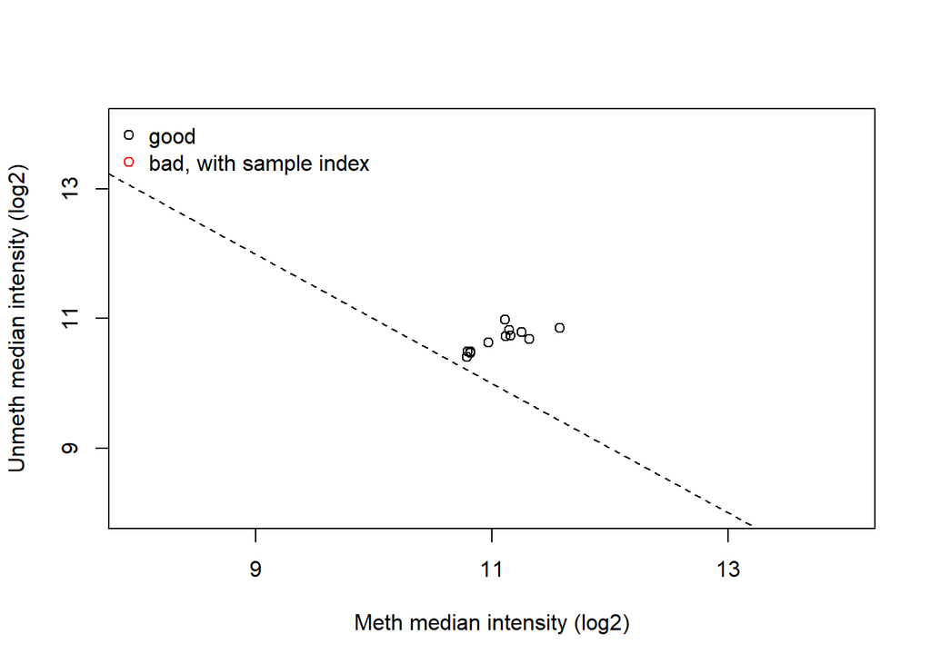

```r
#png("QC.plot2.png")
plotQC(qc)
```

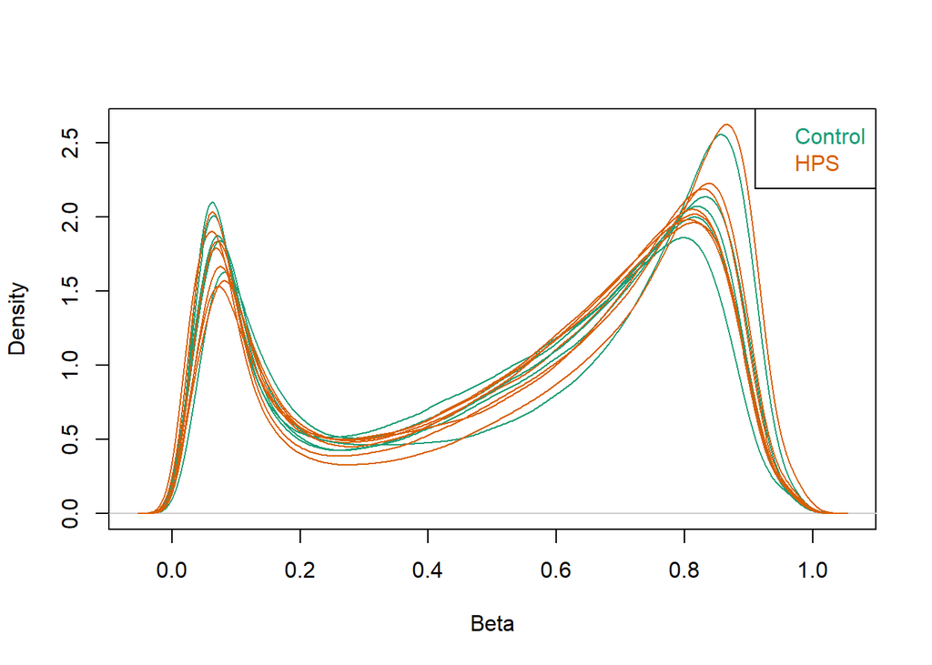

```r
#dev.off()

#Above a certain dashed-line threshold, the probes are hybridizing well
#To further explore the quality of the samples, it is useful to look at the Beta value densities of the samples, with the option to color the densities by group:
densityPlot(MSet, sampGroups = targets$Disease_state)
#binomial distribution suggests good quality of hybridization

phenoData2 <- pData(MSet)
densityPlot(MSet, sampGroups = phenoData2$Disease_state)
```

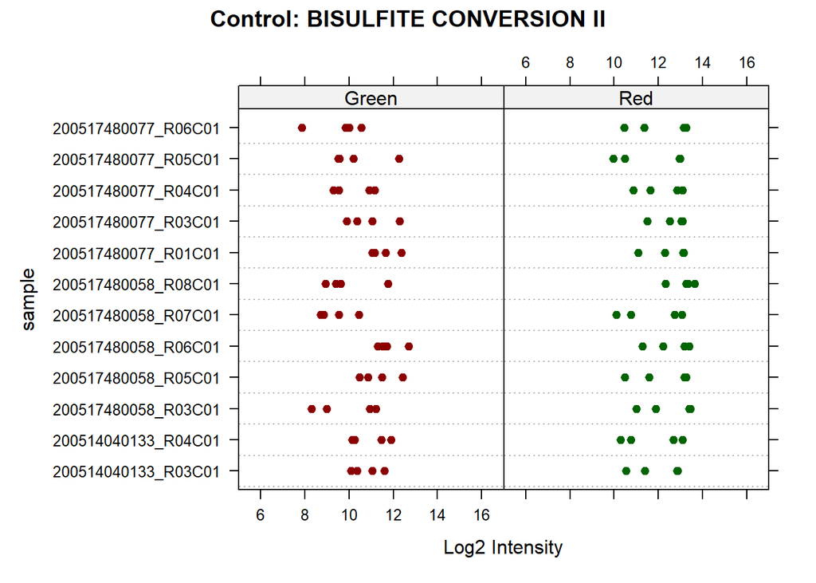

```r
#The EPIC array contains several internal control probes that can be used to assess the quality control of different sample
#preparation steps (bisulfite conversion, hybridization, etc.).
#The values of these control probes are stored in the initial RGChannelSet
#and can be plotted by using the function controlStripPlot and by specifying the control probe type:
#png("Bis_con.png")
controlStripPlot(rgset, controls="BISULFITE CONVERSION II")
```

```r
#Sex prediction

#By looking at the median total intensity of the X chromosome-mapped probes, denoted med(X)med(X),
#and the median total intensity of the Y-chromosome-mapped probes, denoted med(Y)med(Y),
#one can observe two different clusters of points corresponding to which gender the samples belong to.
#To predict the gender, minfi separates the points by using a cutoff on log2med(Y)

#The default cutoff is ???2???2.plotSex expects as input a [Genomic]MethylSet, yet getSex returns a DataFrame.
#Since the algorithm needs to map probes to the X-chr and to the Y-chr, the input of the function
#getSex needs to be a GenomicMethylSet or a GenomicRatioSet.

predictedSex <- getSex(GRset, cutoff = -2)$predictedSex
#predictedSex <- getSex(GRset, cutoff = -2)??

predictedSex
```

```
## 200514040133_R03C01 200514040133_R04C01 200517480058_R03C01 200517480058_R05C01
##                 "M"                 "F"                 "F"                 "M"
## 200517480058_R06C01 200517480058_R07C01 200517480058_R08C01 200517480077_R01C01
##                 "M"                 "F"                 "M"                 "M"
## 200517480077_R03C01 200517480077_R04C01 200517480077_R05C01 200517480077_R06C01
##                 "M"                 "F"                 "F"                 "M"
```

```r
phenoData$gender
```

```
##  [1] "male"   "female" "female" "male"   "male"   "female" "male"   "male"
##  [9] "male"   "female" "female" "male"
```

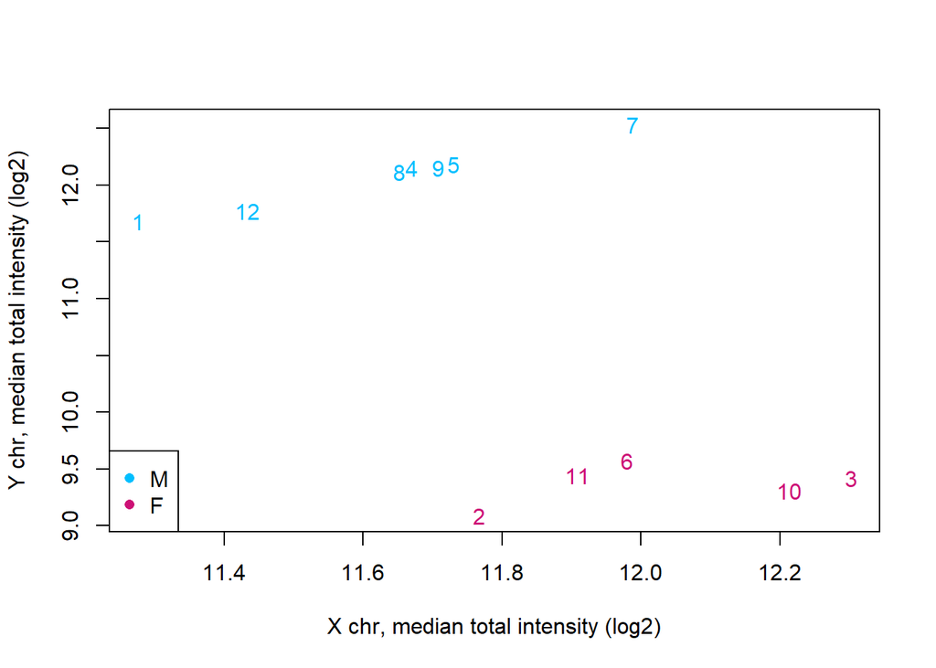

```r
#Genders match!!!!!!!!!!!

#To choose the cutoff to separate the two gender clusters, one can plot med(Y)med(Y) against med(Y)med(Y) with the function plotSex:

GRset<-addSex(GRset)####add sex to GRatio object

#pdf("sex.pdf")
plotSex(GRset)
```

```r
#plotSex(getSex(GRset, cutoff = -2))
#dev.off()
#Evidently, sex is clustering
getSex
```

```
## function (object = NULL, cutoff = -2)
## {
##     .isGenomicOrStop(object)
##     if (is(object, "GenomicMethylSet"))
##         CN <- getCN(object)
##     if (is(object, "GenomicRatioSet"))
##         CN <- getCN(object)
##     xIndex <- which(seqnames(object) == "chrX")
##     yIndex <- which(seqnames(object) == "chrY")
##     .getSex(CN = CN, xIndex = xIndex, yIndex = yIndex, cutoff = cutoff)
## }
## <bytecode: 0x0000024faa9b70e8>
## <environment: namespace:minfi>
```

```r
#function (object = NULL, cutoff = -2)
#{
#  .isGenomicOrStop(object)
#  if (is(object, "GenomicMethylSet"))
#    CN <- getCN(object)
#  if (is(object, "GenomicRatioSet"))
#    CN <- getCN(object)
#  xIndex <- which(seqnames(object) == "chrX")
#  yIndex <- which(seqnames(object) == "chrY")
#  .getSex(CN = CN, xIndex = xIndex, yIndex = yIndex, cutoff = cutoff)
#}
#<bytecode: 0x000002792cf22378>
#  <environment: namespace:minfi>

####detection pvals

detP<-detectionP(rgset)
#Plotting the mean detection p-value for each sample will allow us to gauge whether any samples have many failed probes
#- this will be indicated by a large mean detection p-value. Samples with mean detection p-values exceeding a cutoff
#such as 0.05 can be excluded from further analysis.

dim(detP)
```

```
## [1] 866836     12
```

```r
#[1] 866836     12

head(detP)
```

```
##            200514040133_R03C01 200514040133_R04C01 200517480058_R03C01
## cg18478105        0.000000e+00        0.000000e+00        0.000000e+00
## cg09835024        3.949246e-54        1.165061e-47        0.000000e+00
## cg14361672        0.000000e+00       7.090788e-225        0.000000e+00
## cg01763666       3.010756e-237       3.032061e-118       5.825206e-243
## cg12950382        2.250912e-48        1.053247e-36        3.566504e-53
## cg02115394       2.456112e-301       7.175733e-211        0.000000e+00
##            200517480058_R05C01 200517480058_R06C01 200517480058_R07C01
## cg18478105        0.000000e+00        0.000000e+00        0.000000e+00
## cg09835024       4.360123e-148       1.556075e-100       5.156170e-118
## cg14361672        0.000000e+00        0.000000e+00       1.021777e-196
## cg01763666       5.421277e-307        0.000000e+00       1.126008e-152
## cg12950382        5.248009e-68        6.165371e-18       7.135641e-115
## cg02115394        0.000000e+00        0.000000e+00        0.000000e+00
##            200517480058_R08C01 200517480077_R01C01 200517480077_R03C01
## cg18478105        0.000000e+00        0.000000e+00        0.000000e+00
## cg09835024        0.000000e+00       3.504518e-132       8.516702e-180
## cg14361672        0.000000e+00        0.000000e+00        0.000000e+00
## cg01763666        0.000000e+00        0.000000e+00        0.000000e+00
## cg12950382        1.379887e-48        3.828823e-33        3.809249e-34
## cg02115394        0.000000e+00        0.000000e+00        0.000000e+00
##            200517480077_R04C01 200517480077_R05C01 200517480077_R06C01
## cg18478105        0.000000e+00                   0        0.000000e+00
## cg09835024       3.368449e-213                   0       4.284565e-126
## cg14361672        0.000000e+00                   0        0.000000e+00
## cg01763666        0.000000e+00                   0        0.000000e+00
## cg12950382       2.184938e-110                   0       7.108722e-123
## cg02115394        0.000000e+00                   0        0.000000e+00
```

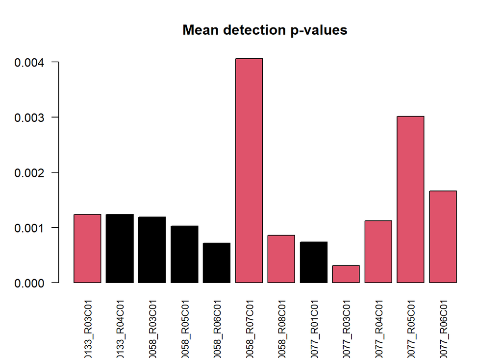

```r
# examine mean detection p-values across all samples to identify any failed samples
#pdf("pvals.detect.pdf")
barplot(colMeans(detP),col=factor(targets$Disease_state),las=2,cex.names=0.8,main="Mean detection p-values")
abline(h=0.05,col="red")
```

```r
#Above 2 lines worked, skipped pdf line and devoff
#barplot(colMeans(detP), las=2, cex.names=0.8, ylab="Mean detection p-values")
#dev.off()

###In case we want to remove samples
keep<-colMeans(detP) < 0.01
rgset<-rgset[,keep]
targets = targets[keep,]
detP = detP[,keep]
dim(detP)
```

```
## [1] 866836     12
```

```r
###probe
keep <- rowSums(detP < 0.01) == ncol(rgset)
#keep<-rowMeans(detP) < 0.01 #FROM 450K script

table(keep)
```

```
## keep
##  FALSE   TRUE
##  29213 837623
```

```r
not.keep<-names(keep[keep=="FALSE"])

rgset <- rgset[keep,]

dim(rgset)
```

```
## [1] 1020321      12
```

```r
#################NORMALIZATION

#BLOCK2: Analysis (in order to standardize, normalize by Quantiles). Do not expect
#huge differences in this case, hence use nominal pvalue to establish differential
#analysis control instead of FDR.
#1. How many CpgS are differentially methylated without considering covariates
#(age, sex…)? That means all, promoter, and promoter plus island.

#If there exist global biological methylation differences between your samples, as for instance a dataset
#with cancer and normal samples, or a dataset with different tissues/cell types, use the preprocessFunnorm function
#as it is aimed for such datasets. On the other hand, if you do not expect global differences between your samples,
#for instance a blood dataset, or one-tissue dataset, use the preprocessQuantile function.
#In our experience, these two normalization procedures perform always better than the functions preprocessRaw,
#preprocessIllumina and preprocessSWAN discussed below. For convenience, these functions are still implemented
#in the minfi package.”

#gRatioSet.Illumina <- preprocessIllumina(rgset)##Illumina
#gRatioSet.SWAN <- preprocessSWAN(rgset,verbose = T)##SWAN
#gRatio.Fun<-preprocessFunnorm(rgset,verbose = T)

#The preprocessQuantile function (Input: RGChannelSet,Output: GenomicRatioSet)implements stratified quantile normalization preprocessing.
#The normalization procedure is applied to the Meth and Unmeth intensities separately. The distribution of type I and type II signals is
#forced to be the same by first quantile normalizing the type II probes across samples and then interpolating a reference distribution to
#which we normalize the type I probes. Since probe types and probe regions are confounded and we know that DNA methylation varies across
#regions we stratify the probes by region before applying this interpolation. Note that this algorithm relies on the assumptions necessary
#for quantile normalization to be applicable and thus is not recommended for cases where global changes are expected such as in cancer-normal
#comparisons as these would be removed by the normalization.As we are comparing different x types, which are globally relatively similar,
#we will apply the preprocessQuantile method to our data.

gRatioSet.quantile <- preprocessQuantile(rgset,verbose = T)##SQN
```

```
## [preprocessQuantile] Mapping to genome.
## [preprocessQuantile] Fixing outliers.
## [preprocessQuantile] Quantile normalizing.
```

```r
class(gRatioSet.quantile)
```

```
## [1] "GenomicRatioSet"
## attr(,"package")
## [1] "minfi"
```

```r
gRatioSet.quantile
```

```
## class: GenomicRatioSet
## dim: 835034 12
## metadata(0):
## assays(2): M CN
## rownames(835034): cg14817997 cg26928153 ... cg07587934 cg16855331
## rowData names(0):
## colnames(12): 200514040133_R03C01 200514040133_R04C01 ...
##   200517480077_R05C01 200517480077_R06C01
## colData names(13): SampleName Basename ... yMed predictedSex
## Annotation
##   array: IlluminaHumanMethylationEPIC
##   annotation: ilm10b4.hg19
## Preprocessing
##   Method: Raw (no normalization or bg correction)
##   minfi version: 1.50.0
##   Manifest version: 0.3.0
```

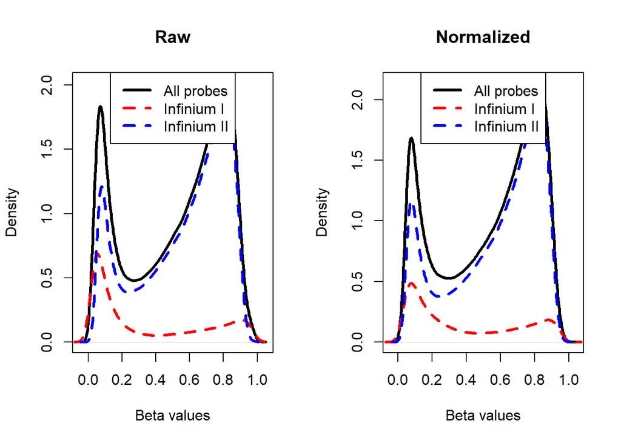

```r
#Compare with the unnormalized data to visualize the effect of the normalization.
#First a comparison of the Beta distributions for the different probe designs.
#This will give an indication of the effectiveness of the within-array normalization.

par(mfrow=c(1,2))
# Plot distributions prior to normalization for sample 1
plotBetasByType(MSet[,1],main="Raw")
# The normalized object is a GenomicRatioSet which does not contain
# the necessary probe info, we need to extract this from the MethylSet first.
typeI <- getProbeInfo(MSet, type = "I")[, c("Name","nCpG")]
typeII <- getProbeInfo(MSet, type = "II")[, c("Name","nCpG")]
probeTypes <- rbind(typeI, typeII)
probeTypes$Type <- rep(x = c("I", "II"), times = c(nrow(typeI), nrow(typeII)))
# Now plot the distributions of the normalized data for sample 1
plotBetasByType(getBeta(gRatioSet.quantile)[,1], probeTypes = probeTypes, main="Normalized",)
```

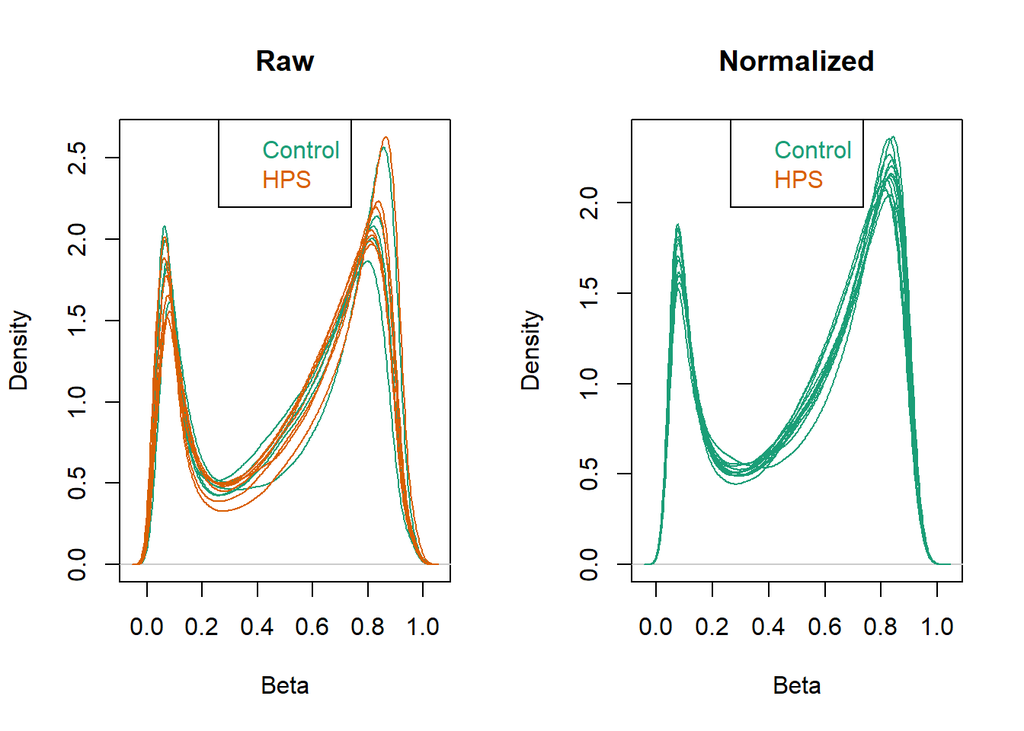

```r
#Evidently, the normalization brought the distributions closer to each other
#Now let’s see how the between-array normalization worked…

# visualise what the data looks like before and after normalization
par(mfrow=c(1,2))
densityPlot(rgset, sampGroups=targets$Disease_state,main="Raw", legend=FALSE)
legend("top", legend = levels(factor(targets$Disease_state)),text.col=brewer.pal(8,"Dark2"))
densityPlot(getBeta(gRatioSet.quantile), sampGroups=targets$Sample_Group,main="Normalized", legend=FALSE)
legend("top", legend = levels(factor(targets$Disease_state)),text.col=brewer.pal(8,"Dark2"))
```

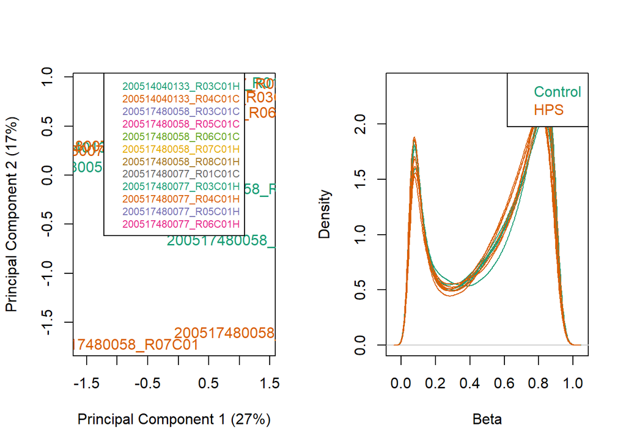

```r
#After normalization of  data is a good time to look at the similarities and differences between the various samples.
#One way to do this is by creating a MDS or Multi-Dimensional Scaling plot. This is a method to graphically represent relationships
#between objects (here the different samples) in multidimensional space onto 2 or 3 dimensional space.
# MDS plots to look at largest sources of variation
# Create color panel

pal <- brewer.pal(8,"Dark2")
# Plot figures
par(mfrow=c(1,2))
plotMDS(getM(gRatioSet.quantile), top=1000, gene.selection="common",
        col=pal[factor(targets$Disease_state)], dim=c(1,2))
legend("top", legend=levels(factor(targets$name)), text.col=pal,
       bg="white", cex=0.7)

#Evidently, 44% of total variance is explained by first 2 Principal Components (PC1=27%, PC2=17%) based on eigenvalues og eigenvectors


############################################################################
densityPlot(getBeta(gRatioSet.quantile), sampGroups = targets$Disease_state)
```

```r
#UNUSED TEST CODE
####Correlations
sample.quantile<-colMeans(getBeta(gRatioSet.quantile),na.rm = T)
#sample.illumina<-colMeans(getBeta(gRatioSet.Illumina),na.rm = T)
#sample.swan<-colMeans(getBeta(gRatioSet.SWAN),na.rm = T)


#mod1 <-lm(as.numeric(sample.quantile)~as.numeric(sample.illumina))##
#modsum<-summary(mod1)

#r2 <- cor.test(as.numeric(sample.quantile),as.numeric(sample.illumina),method="spearman")$estimate
#my.p<-cor.test(as.numeric(sample.quantile),as.numeric(sample.illumina),method="spearman")$p.value
#my.p<-signif(my.p, digits=3)

#png("Quantiles_Illumina.png")
#mylabel = bquote(italic(R)^2 == .(format(r2, digits = 3)))
#plot(as.numeric(sample.quantile)~as.numeric(sample.illumina), main=paste("Correlation", "p-value", my.p, sep=" "), pch=20,col="grey40")

#    ,xlim=c(0,10000),ylim=c(0,10000))
#  plot(as.numeric(cnts[,1])~as.numeric(cnts[,2]), main=paste("Correlation","Pulse Replicates Global", "p-value", my.p, sep=" "), xlab="Ctrl1", ylab="Ctrl2", pch=20)
#abline(mod1, col="red")
# abline(h=0,col="blue1")
#abline(v=0,col="blue1")
#legend('topleft', legend = mylabel, bty = 'n')

#dev.off()

########################################PREPARE GENOME ANNOTATION

ann850k<-getAnnotation(IlluminaHumanMethylationEPICanno.ilm10b4.hg19)
class(ann850k)
```

```
## [1] "DFrame"
## attr(,"package")
## [1] "S4Vectors"
```

```r
ann850k<-as.data.frame(ann850k)
#head(ann850k)

colnames(ann850k)
```

```
##  [1] "chr"
##  [2] "pos"
##  [3] "strand"
##  [4] "Name"
##  [5] "AddressA"
##  [6] "AddressB"
##  [7] "ProbeSeqA"
##  [8] "ProbeSeqB"
##  [9] "Type"
## [10] "NextBase"
## [11] "Color"
## [12] "Probe_rs"
## [13] "Probe_maf"
## [14] "CpG_rs"
## [15] "CpG_maf"
```

[output cut: 31 more lines]

```r
############################FILTERING

#Poor performing probes can obscure the biological signals in the data and are generally filtered out prior to
#differential methylation analysis. As the signal from these probes is unreliable, by removing them we perform fewer
#statistical tests and thus lower the multiple testing penalty. We filter out probes that have failed in one or more
#samples based on detection p-value.

#UNUSED CODE
#???????????????????START
# ensure probes are in the same order in the mSetSq and detP objects
#detP <- detectionP(rgSet)
#detP <- detP[match(featureNames(mSetSq),rownames(detP)),]

# remove any probes that have failed in one or more samples; this next line
# checks for each row of detP whether the number of values < 0.01 is equal
# to the number of samples (TRUE) or not (FALSE)
#keep <- rowSums(detP < 0.01) == ncol(mSetSq)
#table(keep)
# Subset the GenomicRatioSet
#mSetSqFlt <- mSetSq[keep,]
#mSetSqFlt
#?????????????????????STOP

#Not interested in imprinting or sexual methylation studies. We are instead interested in disease state.etc.
keep <- !(featureNames(gRatioSet.quantile) %in% ann850k$Name[ann850k$chr %in% c("chrX","chrY")])

table(keep)
```

```
## keep
##  FALSE   TRUE
##  18922 816112
```

```r
gRatioSet.quantile <- gRatioSet.quantile[keep,]
gRatioSet.quantile
```

```
## class: GenomicRatioSet
## dim: 816112 12
## metadata(0):
## assays(2): M CN
## rownames(816112): cg14817997 cg26928153 ... cg07660283 cg09226288
## rowData names(0):
## colnames(12): 200514040133_R03C01 200514040133_R04C01 ...
##   200517480077_R05C01 200517480077_R06C01
## colData names(13): SampleName Basename ... yMed predictedSex
## Annotation
##   array: IlluminaHumanMethylationEPIC
##   annotation: ilm10b4.hg19
## Preprocessing
##   Method: Raw (no normalization or bg correction)
##   minfi version: 1.50.0
##   Manifest version: 0.3.0
```

```r
##Remove probes with SNPs at CpG or SBE site (These are variable among individuals, so we remove the corresponding probes for those Cpg islands)
#####get snp info

snp.info<-getSnpInfo(gRatioSet.quantile)
snp.info
```

```
## DataFrame with 816112 rows and 6 columns
##               Probe_rs Probe_maf      CpG_rs   CpG_maf      SBE_rs   SBE_maf
##            <character> <numeric> <character> <numeric> <character> <numeric>
## cg14817997          NA        NA          NA        NA          NA        NA
## cg26928153          NA        NA          NA        NA          NA        NA
## cg16269199          NA        NA          NA        NA          NA        NA
## cg13869341          NA        NA          NA        NA          NA        NA
## cg14008030          NA        NA          NA        NA          NA        NA
## ...                ...       ...         ...       ...         ...       ...
## cg16817496 rs139240849    0.0256          NA        NA          NA        NA
## cg15964525          NA        NA rs150984102    0.0495          NA        NA
## cg05111475 rs150984102    0.0495          NA        NA          NA        NA
## cg07660283          NA        NA          NA        NA          NA        NA
## cg09226288          NA        NA          NA        NA          NA        NA
```

```r
####mapping

gRatioSet.quantile<- dropLociWithSnps(gRatioSet.quantile)
gRatioSet.quantile
```

```
## class: GenomicRatioSet
## dim: 787044 12
## metadata(0):
## assays(2): M CN
## rownames(787044): cg14817997 cg26928153 ... cg07660283 cg09226288
## rowData names(0):
## colnames(12): 200514040133_R03C01 200514040133_R04C01 ...
##   200517480077_R05C01 200517480077_R06C01
## colData names(13): SampleName Basename ... yMed predictedSex
## Annotation
##   array: IlluminaHumanMethylationEPIC
##   annotation: ilm10b4.hg19
## Preprocessing
##   Method: Raw (no normalization or bg correction)
##   minfi version: 1.50.0
##   Manifest version: 0.3.0
```

```r
densityPlot(getBeta(gRatioSet.quantile), sampGroups = targets$Disease_state)

#UNUSED CODE
#?????????START
#phenoData <- pData(MSet)
#densityPlot(MSet, sampGroups = phenoData$Sample_Group)
#??????????STOP

####get values to proceed with analysis
betas<-getBeta(gRatioSet.quantile)
head(betas)
```

[output not shown]

```
##            200514040133_R03C01 200514040133_R04C01 200517480058_R03C01
## cg14817997           0.7918796           0.8732455           0.8886405
## cg26928153           0.8437874           0.8207997           0.8223887
## cg16269199           0.7194141           0.7069658           0.7087748
## cg13869341           0.8252505           0.8337070           0.8099474
## cg14008030           0.6943696           0.6285105           0.7347957
## cg12045430           0.2664168           0.3185365           0.2724465
##            200517480058_R05C01 200517480058_R06C01 200517480058_R07C01
## cg14817997           0.8623043           0.8266810           0.8531627
## cg26928153           0.8201918           0.8371943           0.8463829
## cg16269199           0.6663996           0.6465055           0.6819608
## cg13869341           0.8662020           0.8520057           0.7795761
## cg14008030           0.7291086           0.7271401           0.7177491
## cg12045430           0.2828381           0.2386598           0.2902111
##            200517480058_R08C01 200517480077_R01C01 200517480077_R03C01
## cg14817997           0.7849426           0.8655565           0.8011105
## cg26928153           0.8073144           0.8186920           0.8020678
## cg16269199           0.6480420           0.6719211           0.6868221
## cg13869341           0.8785273           0.8435441           0.8329103
## cg14008030           0.7837854           0.7663428           0.7676364
## cg12045430           0.2245011           0.2553189           0.2452914
##            200517480077_R04C01 200517480077_R05C01 200517480077_R06C01
## cg14817997           0.8086201           0.8111062           0.7851221
## cg26928153           0.8344472           0.8413033           0.8246813
## cg16269199           0.6704204           0.7303534           0.6577748
## cg13869341           0.8339514           0.8247543           0.8064623
## cg14008030           0.7576194           0.7478939           0.7992715
## cg12045430           0.2569725           0.2720306           0.2732287
```

```r
dim(betas)
```

```
## [1] 787044     12
```

```r
betas <- rmSNPandCH(betas, dist=2, mafcut=0.05,rmcrosshyb = T,rmXY = T) ### get out SNPs of my samples
```

```
## Probe IDs from EPICv1 or earlier detected. Proceeding...
## see ?DMRcatedata and browseVignettes('DMRcatedata') for documentation
## loading from cache
## see ?DMRcatedata and browseVignettes('DMRcatedata') for documentation
## loading from cache
## see ?DMRcatedata and browseVignettes('DMRcatedata') for documentation
## loading from cache
```

```r
#Probe IDs from EPICv1 or earlier detected. Proceeding...
#Cannot connect to ExperimentHub server, using 'localHub=TRUE' instead
#Using 'localHub=TRUE'
#If offline, please also see BiocManager vignette section on offline use
#snapshotDate(): 2024-05-28
#see ?DMRcatedata and browseVignettes('DMRcatedata') for documentation
#loading from cache
#see ?DMRcatedata and browseVignettes('DMRcatedata') for documentation
#loading from cache
#see ?DMRcatedata and browseVignettes('DMRcatedata') for documentation
#loading from cache

head(betas)
```

```
##            200514040133_R03C01 200514040133_R04C01 200517480058_R03C01
## cg26928153           0.8437874           0.8207997           0.8223887
## cg16269199           0.7194141           0.7069658           0.7087748
## cg13869341           0.8252505           0.8337070           0.8099474
## cg24669183           0.7723263           0.8285776           0.7508805
## cg26679879           0.1475413           0.1999579           0.2250394
## cg15560884           0.6578854           0.6836458           0.6844488
##            200517480058_R05C01 200517480058_R06C01 200517480058_R07C01
## cg26928153           0.8201918           0.8371943           0.8463829
## cg16269199           0.6663996           0.6465055           0.6819608
## cg13869341           0.8662020           0.8520057           0.7795761
## cg24669183           0.7149492           0.8258691           0.5361856
## cg26679879           0.2183285           0.1818550           0.1273142
## cg15560884           0.7096099           0.7163692           0.7367071
##            200517480058_R08C01 200517480077_R01C01 200517480077_R03C01
## cg26928153           0.8073144           0.8186920           0.8020678
## cg16269199           0.6480420           0.6719211           0.6868221
## cg13869341           0.8785273           0.8435441           0.8329103
## cg24669183           0.6991834           0.7851517           0.7516950
## cg26679879           0.1749955           0.1949919           0.1995829
## cg15560884           0.6452724           0.6877258           0.6650607
##            200517480077_R04C01 200517480077_R05C01 200517480077_R06C01
## cg26928153           0.8344472           0.8413033           0.8246813
## cg16269199           0.6704204           0.7303534           0.6577748
## cg13869341           0.8339514           0.8247543           0.8064623
## cg24669183           0.7397117           0.6623212           0.7570796
## cg26679879           0.1929930           0.1267514           0.1721409
## cg15560884           0.6935400           0.6628772           0.6859714
```

```r
dim(betas)
```

```
## [1] 742714     12
```

```r
#Calculate M-values for statistical analysis: as previously mentioned, M-values have nicer statistical properties
#and are thus better for use in statistical analysis of methylation data
M<-getM(gRatioSet.quantile)
head(M)
```

```
##            200514040133_R03C01 200514040133_R04C01 200517480058_R03C01
## cg14817997            1.927863           2.7843504            2.996375
## cg26928153            2.433368           2.1954568            2.211097
## cg16269199            1.358380           1.2705710            1.283192
## cg13869341            2.239544           2.3258128            2.091429
## cg14008030            1.183915           0.7586153            1.470239
## cg12045430           -1.461275          -1.0971775           -1.417080
##            200517480058_R05C01 200517480058_R06C01 200517480058_R07C01
## cg14817997           2.6467138           2.2539010            2.538602
## cg26928153           2.1895024           2.3624112            2.461971
## cg16269199           0.9982667           0.8709746            1.100484
## cg13869341           2.6946465           2.5253213            1.822409
## cg14008030           1.4284192           1.4140731            1.346502
## cg12045430          -1.3423224          -1.6735860           -1.290287
##            200517480058_R08C01 200517480077_R01C01 200517480077_R03C01
## cg14817997           1.8678657            2.686628            2.010034
## cg26928153           2.0668816            2.174878            2.018717
## cg16269199           0.8806838            1.034249            1.132954
## cg13869341           2.8544545            2.430708            2.317539
## cg14008030           1.8579946            1.713596            1.724039
## cg12045430          -1.7884026           -1.544323           -1.621423
##            200517480077_R04C01 200517480077_R05C01 200517480077_R06C01
## cg14817997            2.079022            2.102315           1.8693996
## cg26928153            2.333529            2.406354           2.2338571
## cg16269199            1.024439            1.437525           0.9426475
## cg13869341            2.328358            2.234585           2.0589926
## cg14008030            1.644199            1.568802           1.9934405
## cg12045430           -1.531802           -1.420109          -1.4113921
```

```r
dim(M)
```

```
## [1] 787044     12
```

```r
#Beta and M dimensions are NO LONGER identical. Is this a problem? There is no
#mention or example of similarly adjusting M in notes or videos. Therefore, I will
#leave this alone

#####
#ann450k<-getAnnotation(IlluminaHumanMethylation450kanno.ilmn12.hg19)
#M <- getM(gRatioSet.quantile)

#Confiming that beta names and target names are in SAME ORDER:
colnames(betas)
```

```
##  [1] "200514040133_R03C01" "200514040133_R04C01" "200517480058_R03C01"
##  [4] "200517480058_R05C01" "200517480058_R06C01" "200517480058_R07C01"
##  [7] "200517480058_R08C01" "200517480077_R01C01" "200517480077_R03C01"
## [10] "200517480077_R04C01" "200517480077_R05C01" "200517480077_R06C01"
```